# Modelización LiDAR

Jessica Bernal

23/4/2022

## Contenido:

1. Cargar librerías
2. Preparar base de datos
3. Regresión paramétrica
4. Regresión no paramétrica
5. Análisis de errores de los modelos

### 1. Cargar librerías

Para empezar, cargamos las librerías con las que vamos a trabajar (las instalamos previamente en caso de no tenerlas)

```r
#install.packages("Metrics")
```

```r
rm(list=ls())
pck <- (c("tidyr", "dplyr", "readxl", "ggplot2", "randomForest", "car", "Metrics"))
sapply(pck, require, character.only=TRUE)
```

```
##        tidyr        dplyr       readxl      ggplot2 randomForest          car
##         TRUE         TRUE         TRUE         TRUE         TRUE         TRUE
##      Metrics
##         TRUE
```

### 2. Preparar base de datos

A continuación, procedemos a intersectar el archivo de métricas LiDAR que hemos generado con los datos del inventario de campo. Para ello, usaremos campos comunes como el *fid* y el *ID*.

```r
inventario <- read_excel ("C:/Geoforest/Lidar_II/Parcelas/resultado parcelas_.xls", sheet=1)
metricas <- read_excel ("C:/Geoforest/Lidar_II/Datos_Lidar/metricas.xlsx")

ds <- merge(inventario, metricas, by=c("fid", "ID"))
```

### 3. Regresión paramétrica

En este apartado necesitamos entender la relación entre una variable respuesta (dasométrica o dendométrica) medida en campo a través del inventario, y un conjunto de variables predictivas obtenidas de las métricas de los datos LiDAR. Un métido estadístico ampliamente utilizado es la regresión lineal simple o multivariable, no obstante, este modelo requiere que nuestros datos cumplan cinco asunciones:

#### 3.1 Relacion lineal entre las variables

Es decir, que exista una relación lineal entre cada predictor y la variable respuesta. La forma mas fácil de evaluar es visualizar la relación entre cada predictor (variable X) y la variable respuesta (variable Y). En este sentido, debemos de evaluar si los puntos entre la variable X e Y siguen una linea recta. En el siguiente ejemplo usaremos la variable dependiente altura (H) y algunas de las variables más sensibles a la altura como son el percentil 90 y el percentil 50.

```r
colnames(ds)
```

```
##  [1] "fid"         "ID"          "Nombre.x"    "Radio.x"     "N_pies_ha"
##  [6] "G_m2_ha"     "Dg_cm"       "dmedio_cm"   "Ho_Assman_m" "hmedia_m"
## [11] "Nombre.y"    "XPAR"        "YPAR"        "Radio.y"     "Area_m2"
## [16] "Perimeter_"  "min_x"       "min_y"       "max_x"       "max_y"
## [21] "all"         "min"         "max"         "avg"         "qav"
## [26] "std"         "ske"         "kur"         "p05"         "p10"
## [31] "p25"         "p50"         "p75"         "p90"         "p95"
## [36] "b10"         "b20"         "b30"         "b40"         "b50"
## [41] "b60"         "b70"         "b80"         "b90"         "cov_gap"
## [46] "dns_gap"
```

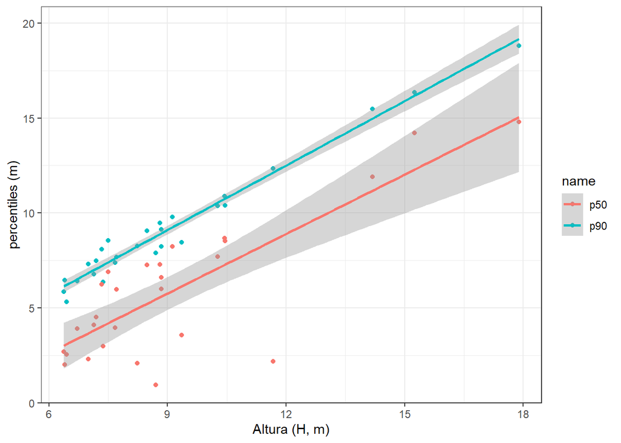

```r
library(ggplot2)
# Ejemplo
ds %>% dplyr::select(p90, p50, hmedia_m) %>%
  pivot_longer(cols = -hmedia_m) %>%
  ggplot(aes(x = hmedia_m, y = value, color = name)) + geom_point()+
  stat_smooth(aes(), method="lm", formula=y ~ x) +theme_bw()+
  ylab("percentiles (m)")+ xlab("Altura (H, m)")
```

Como vemos la relación es razonablemente buena. Podemos comprobar también con en el test de correlación de Pearson, incluso con percentiles bajos de hasta 50 (r=0.80, p-value < 3.1e-07):

```r
cor.test(ds$p50, ds$hmedia_m, method=c("pearson"))
```

```
##
##  Pearson's product-moment correlation
##
## data:  ds$p50 and ds$hmedia_m
## t = 6.9025, df = 25, p-value = 3.1e-07
## alternative hypothesis: true correlation is not equal to 0
## 95 percent confidence interval:
##  0.6209342 0.9098540
## sample estimates:
##       cor
## 0.8098524
```

En el caso que esta relación no fuera lineal, tendríamos varias opciones:

1. Aplicar una transformación (ej. Logit, BoxTransform) para linearizar el problema.
2. Anadir otra variable al modelo. Es decir, si la relación entre la variable X e Y sigue una función potencial podríamos ajustar mediante *Y = aX^2 + b*.
3. Eliminar dicha variable como variable predictora ya que en el caso extremo una relación no lineal puede no ser de gran utilidad en el modelo.

#### 3.2 Multicolinearidad

En el caso de regresiones multivariables, este método requiere que no exista una correlación entre los predictores, ya que una multicolinearidad causaría incertidumbres en los coeficientes del modelo. Un método generalmente empleado para detectar multicolinearidad es el **factor de inflación de la varianza (FIV)**, el cual mide el grado de la correlación entre los predictores del modelo. Una regla establecida es que si el FIV entre 2 predictores se aproxima a un valor de 1 indicaría no correlacion, valores entre 1 y 5 una correlación moderada, y mayores de 5 una correlación severa.

En el ejercicio siguiente procederemos a evaluar la multicolinearidad entre un conjunto de variables predictoras del área basimétrica (*G_m2_ha*). Para ello, usaremos predictores como percentiles y bicentiles, cobertura y densidad de huecos (ej *p90, b50, cov_gap, dns_gap*)

```r
#Ajustamos el modelo de regresion
model <- lm(G_m2_ha ~ p90 + b50 + cov_gap + dns_gap, data = ds)

# Visualizamos los resultados del modelo

summary(model)
```

```
##
## Call:
## lm(formula = G_m2_ha ~ p90 + b50 + cov_gap + dns_gap, data = ds)
##
## Residuals:
##     Min      1Q  Median      3Q     Max
## -4.0532 -2.3849 -0.2598  1.7698  7.1832
##
## Coefficients:
##             Estimate Std. Error t value Pr(>|t|)
## (Intercept) 18.57124    7.96077   2.333  0.02920 *
## p90          1.59053    0.34128   4.660  0.00012 ***
## b50         -0.12078    0.08897  -1.358  0.18834
## cov_gap     -0.20388    0.06208  -3.284  0.00339 **
## dns_gap      0.04747    0.09581   0.495  0.62520
## ---
## Signif. codes:  0 '***' 0.001 '**' 0.01 '*' 0.05 '.' 0.1 ' ' 1
##
## Residual standard error: 2.965 on 22 degrees of freedom
## Multiple R-squared:  0.9106, Adjusted R-squared:  0.8943
## F-statistic: 56.01 on 4 and 22 DF,  p-value: 3.217e-11
```

Los resultados del modelo muestran un *R-squared*: 0.8943. Adicionalmente, podemos observar un *F-statistic*: 56.01 y su correspondiente *p-value*: 3.217e-11, lo que indica que el modelo se ajustó de forma significativa. Además, los predictores *p90* y *cov_gap* son estadísticamente significativos a un nivel de significancia de 0.01, mientras *b50* y *dns_gap* no mostraron ningun beneficio para el modelo. Una vez hecha la evaluación de la robustez del modelo, pasamos a calcular su FIV.

```r
#Calcular FIV para cada predictor del modelo
vif(model)
```

```
##      p90      b50  cov_gap  dns_gap
## 3.604999 5.545200 4.018563 4.340787
```

Aunque la mayoría de valores muestran una colinearidad moderada, esta es especialmente preocupante para el caso de *b50*, la cual supera valores de 5. Por lo tanto, es razonable intentar ajustar el modelo con sus 2 variables más significantes *p90*, y *cov_gap*. En cierto sentido, este proceso nos llevaría a una reducción de variables. No olvidemos que otra forma de visualizar las correlaciones entre los predictores es a través de una matriz de correlación.

A continuación, probamos si el modelo se ve afectado después de eliminar las variables *b50* y *dns_gap*.

```r
#Ajustamos el modelo de regresion
model <- lm(G_m2_ha ~ p90 + cov_gap, data = ds)

# Visualicemos los resultados del modelo

summary(model)
```

```
##
## Call:
## lm(formula = G_m2_ha ~ p90 + cov_gap, data = ds)
##
## Residuals:
##     Min      1Q  Median      3Q     Max
## -4.8357 -2.1538 -0.4031  1.8874  6.2756
##
## Coefficients:
##             Estimate Std. Error t value Pr(>|t|)
## (Intercept)  15.8851     2.4572   6.465 1.10e-06 ***
## p90           1.7161     0.1961   8.749 6.25e-09 ***
## cov_gap      -0.2550     0.0338  -7.546 8.75e-08 ***
## ---
## Signif. codes:  0 '***' 0.001 '**' 0.01 '*' 0.05 '.' 0.1 ' ' 1
##
## Residual standard error: 2.963 on 24 degrees of freedom
## Multiple R-squared:  0.9026, Adjusted R-squared:  0.8944
## F-statistic: 111.2 on 2 and 24 DF,  p-value: 7.328e-13
```

Es importante resaltar que existen otros métodos estadísticos que son menos restrictivos al efecto de la multicolinearidad como regresiones parciales de mínimos cuadrados.

#### 3.3 Independencia

Otro importante aspecto en la regresión es conocer si las observaciones son independientes. Este elemento es particularmente relevante en series temporales y podría ser evaluado mediante el test de Durbin-Watson.

#### 3.4 Homocedasticidad

Para evaluar si la varianza de los residuales es constante a lo largo del modelo procedemos a realizar una análisis de residuales. La forma mas simple es visualizar la dispersión de los residuales a lo largo de las predicciones del modelo.

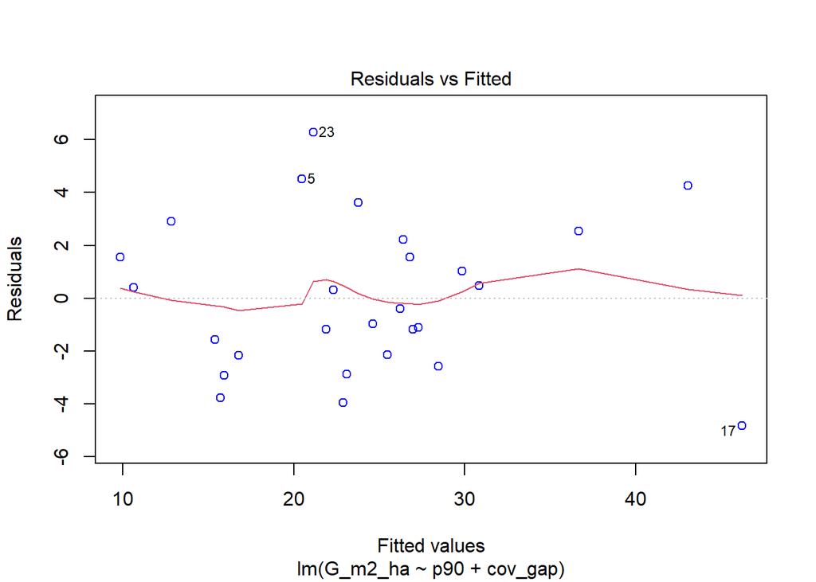

```r
plot(model, which=1, col=c("blue"))
```

El gráfico de arriba sugiere que la varianza de los residuales es homogénea para todo el rango de valores de las predicciones. En caso contrario, deberiamos optar por redefinir las variables o incluso reevaluar sus distribuciones para que cumplan con la normalidad.

#### 3.5 Normalidad multivariable

Por último, debemos asegurarnos que los residuales del modelo siguen una distribución normal mediante una Q-Q plot. Además, podemos proceder con algunos de los test de normalidad como los de *Shapiro-Wilk*, *Kolmogorov-Smironov*, *Jarque-Barre*, o *D’Agostino-Pearson*.

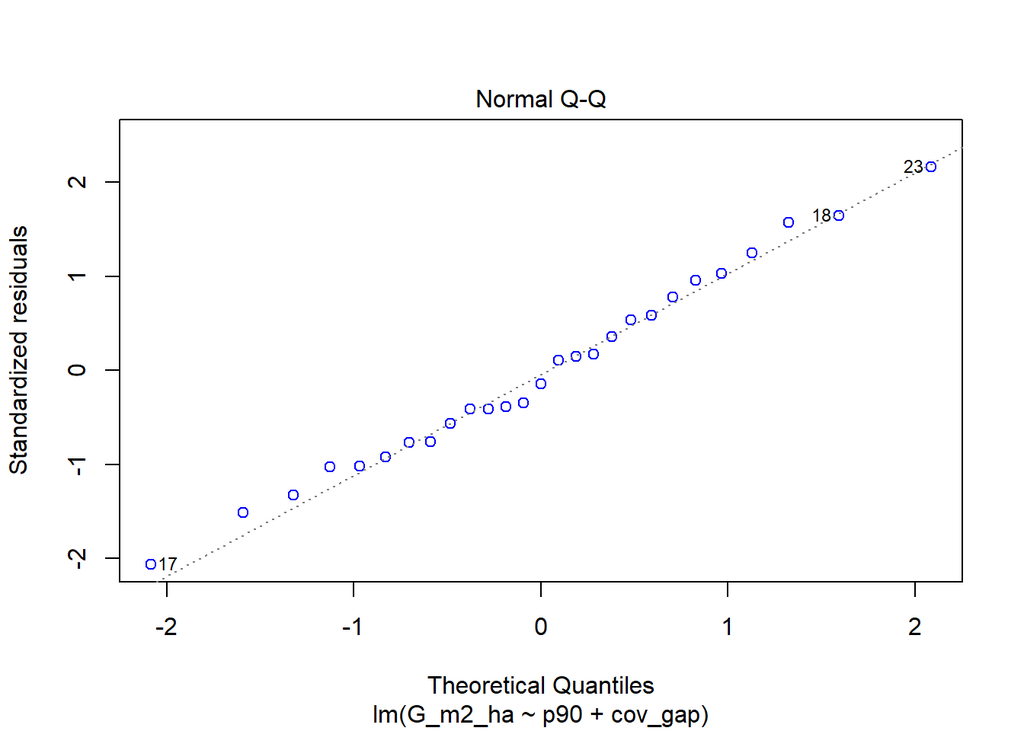

```r
plot(model, which=2, col=c("blue"))
```

### 4. Regresión no paramétrica

Los métodos de regresión no paramétrica son particularmente útiles para casos en los que tratemos estructuras de datos mas complejas como un conjunto de correlaciones no lineales entre variables. Aunque el éxito del ajuste de dichos modelos depende en gran medida de la dimensión del set de datos, dichos modelos solventan satisfactoriamente los requerimientos de los modelos paramétricos.

Aunque un set de datos de 27 observaciones podría ser bastante limitado para un modelo robusto vamos a proceder a ajustar uno de los métodos estadísticos mas ampliamente usados como es el *Random Forest*.

```r
model1 <- randomForest(G_m2_ha ~ p90 + cov_gap, data = ds, importance = TRUE)
model1
```

```
##
## Call:
##  randomForest(formula = G_m2_ha ~ p90 + cov_gap, data = ds, importance = TRUE)
##                Type of random forest: regression
##                      Number of trees: 500
## No. of variables tried at each split: 1
##
##           Mean of squared residuals: 13.60345
##                     % Var explained: 83.02
```

#### 5. Análisis de errores de los modelos

Por último pasaremos a estudiar la fiabilidad de los modelos. Aunque hemos podido comprobar su coeficiente de determinación, procedamos a visualizar las predicciones de ambos modelos frente a los datos medido en campo. Debemos tener en cuenta que el ajuste del modelo se ha realizado en la totalidad del tamano muestral y no hemos considerado un dataset independiente para la validación. Esto podría realizarse alternativamente mediante métodos de *bootstrapping*.

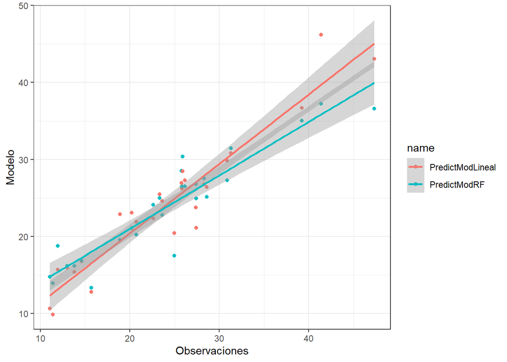

```r
PredictModLineal <- predict(model, data=ds)
PredictModRF <- predict(model1, data=ds)
Observed <- ds$G_m2_ha

tmp <- data.frame(PredictModLineal, PredictModRF, Observed)

tmp %>% dplyr::select(PredictModLineal, PredictModRF, Observed) %>%
  pivot_longer(cols = -Observed) %>%
  ggplot(aes(x = Observed, y = value, color = name)) + geom_point()+
  stat_smooth(aes(), method="lm", formula=y ~ x) +theme_bw()+
  ylab("Modelo")+ xlab("Observaciones")
```

Pasemos ahora a calcular el error medio cuadrático de ambos modelos. Hay que recordar que la inventariación con datos LiDAR no incluye error muestral sino error de estimación de la muestra.

```r
RMSE_lineal <- rmse(tmp$Observed, tmp$PredictModLineal)
RMSE_lineal
```

```
## [1] 2.794008
```

```r
RMSE_RF <- rmse(tmp$Observed, tmp$PredictModRF)
RMSE_RF
```

```
## [1] 3.688286
```